```python
__nbid__ = '0025'
__author__ = 'Alice Jacques <alice.jacques@noirlab.edu>, Robert Nikutta <robert.nikutta@noirlab.edu>'
__version__ = '20240606' # yyyymmdd; version datestamp of this notebook
__datasets__ = ['vhs_dr5', 'gaia_dr3']
__keywords__ = ['stars','proper motions','crossmatch','SMC','LMC']
```

# Exploring Stellar Populations Around the Magellanic Clouds with VHS DR5

*by Alice Jacques & Robert Nikutta*

- Goals & notebook summary
- Disclaimer & Attribution
- Imports & setup
- Selection of young and old stellar populations around the LMC and SMC
- Identifying points only in the Y or O region, then querying for corresponding data
- Stellar proper motions
- Plot the spatial density morphology maps
- Using Gaia DR3 instead of Gaia DR2
- Resources and references

# Goals

To reproduce Figures 3, 4, and 10 from [El Youssoufi et al. (2021)](https://arxiv.org/abs/2104.08054) "Stellar substructures in the periphery of the Magellanic Clouds with the VISTA Hemisphere Survey from the red clump and other tracers". These figures focus on detailing the morphological features in the outskirts of the Magellanic Clouds. In particular, this notebook will help confirm the substructures noted in Figure 10 of the paper.

# Summary

In their paper, El Youssoufi et al. present a detailed analysis of the spatial distribution of different stellar populations in the periphery of the Magellanic Clouds (MCs) using data from the VISTA Hemisphere Survey ([VHS; McMahon et al. 2013](https://ui.adsabs.harvard.edu/abs/2013Msngr.154...35M/abstract)). In order to understand the ways in which the MCs interact with each other, it is very important to examine the stellar substructures that surround the MCs. We can use the VHS survey data to verify the existence of known substructures and discover new ones by studying the morphology surrounding the MCs over a continuous area.

NOTE: The paper also uses data from the VISTA near-infrared YJKs survey of the MCs system ([VMC; Cioni et al. 2011](https://ui.adsabs.harvard.edu/abs/2011A%26A...527A.116C/abstract)), which we will not be using in this notebook.

# Disclaimer & attribution

## Disclaimers

Note that using the Astro Data Lab constitutes your agreement with our minimal [Disclaimers](https://datalab.noirlab.edu/disclaimers.php).

## Acknowledgments

If you use **Astro Data Lab** in your published research, please include the text in your paper's Acknowledgments section:

*This research uses services or data provided by the Astro Data Lab, which is part of the Community Science and Data Center (CSDC) Program of NSF NOIRLab. NOIRLab is operated by the Association of Universities for Research in Astronomy (AURA), Inc. under a cooperative agreement with the U.S. National Science Foundation.*

If you use **SPARCL jointly with the Astro Data Lab platform** (via JupyterLab, command-line, or web interface) in your published research, please include this text below in your paper's Acknowledgments section:

*This research uses services or data provided by the SPectra Analysis and Retrievable Catalog Lab (SPARCL) and the Astro Data Lab, which are both part of the Community Science and Data Center (CSDC) Program of NSF NOIRLab. NOIRLab is operated by the Association of Universities for Research in Astronomy (AURA), Inc. under a cooperative agreement with the U.S. National Science Foundation.*

In either case **please cite the following papers**:

- Data Lab concept paper: Fitzpatrick et al., "The NOAO Data Laboratory: a conceptual overview", SPIE, 9149, 2014, https://doi.org/10.1117/12.2057445
- Astro Data Lab overview: Nikutta et al., "Data Lab - A Community Science Platform", Astronomy and Computing, 33, 2020, https://doi.org/10.1016/j.ascom.2020.100411

If you are referring to the Data Lab JupyterLab / Jupyter Notebooks, cite:

- Juneau et al., "Jupyter-Enabled Astrophysical Analysis Using Data-Proximate Computing Platforms", CiSE, 23, 15, 2021, https://doi.org/10.1109/MCSE.2021.3057097

If publishing in a AAS journal, also add the keyword: `\facility{Astro Data Lab}`

And if you are using SPARCL, please also add `\software{SPARCL}` and cite:

- Juneau et al., "SPARCL: SPectra Analysis and Retrievable Catalog Lab", Conference Proceedings for ADASS XXXIII, 2024 https://doi.org/10.48550/arXiv.2401.05576

The NOIRLab Library maintains [lists of proper acknowledgments](https://noirlab.edu/science/about/scientific-acknowledgments) to use when publishing papers using the Lab's facilities, data, or services.

# Imports and setup

```python
# 3rd party imports
import numpy as np
import pylab as plt
%matplotlib inline
from matplotlib.patches import Ellipse
from matplotlib.colors import LogNorm
from shapely.geometry import Polygon, Point
import pandas as pd

# Data Lab imports
from dl import queryClient as qc

# plots default setup
plt.rcParams['font.size'] = 14
```

## Selection of young and old stellar populations around the LMC and SMC

First we define the polygon regions that separate two different classes of objects: young stars (Y region) and old stars (O region). The polygon vertex coordinates listed here were first established by [Cioni et al. (2014)](https://arxiv.org/pdf/1306.4336.pdf) and [Cioni et al. (2016)](https://arxiv.org/pdf/1510.07647.pdf), then later refined in Section 2.1 of [El Youssoufi et al. (2019)](https://arxiv.org/pdf/1908.08545.pdf), and then refined further in Section 2.2 of their [2021 paper](https://arxiv.org/abs/2104.08054). The polygon vertices coordinates are in the J-Ks / Ks color-magnitude diagram.

```python
# Define polygon regions
polygon_Y = Polygon([(-0.6, 18.8), (0.2, 18.8), (0.4,17.5), (0.18,17), (0,16.5), (0,16), (0.4,16), (0.4,16.5), (0.5,16), (1,10), (-0.6,10)])
polygon_O = Polygon([(0.2,18.8), (0.6,18.8), (0.6,16), (1.2,12), (2.5,12), (2.5,10), (1,10), (0.5,16), (0.4, 16.5), (0.4,17.5)])
```

Here we write the query to extract the Ks magnitude and J-Ks color from the VHS DR5 vhs_cat_v3 table for points that are near the LMC and SMC. We compare the resulting plot with the leftmost plot in Figure 3 of [El Youssoufi et al. (2021)](https://arxiv.org/abs/2104.08054).

```python
query = """
SELECT
    jmkspnt,ksapermag3
FROM
    vhs_dr5.vhs_cat_v3
WHERE
    jmkspnt!='NaN' AND ksapermag3 !='NaN' AND japermag3 !='NaN'
    AND (dec2000<=-49.73 AND dec2000>-99.73)
    AND ((ra2000<=130 AND ra2000>0) OR (ra2000<=360 AND ra2000>340))
"""
print(query)
```

```
SELECT
    jmkspnt,ksapermag3
FROM
    vhs_dr5.vhs_cat_v3
WHERE
    jmkspnt!='NaN' AND ksapermag3 !='NaN' AND japermag3 !='NaN'
    AND (dec2000<=-49.73 AND dec2000>-99.73)
    AND ((ra2000<=130 AND ra2000>0) OR (ra2000<=360 AND ra2000>340))
```

```python
res = qc.query(sql=query, timeout=600, fmt='pandas')
```

We define a little helper function to make computing 2D histograms easier.

```python
def compute_nbins(x,y,binsize,extent=None):
    """Compute the needed number of x and y bins.

    From the x and y data, and the desired binsize (identical for x and y),
    computes the number of needed x and y bins. If 'extent' is given, trim
    x and y data to the limits given in 'extent' first. Otherwise, use the
    full data range.

    Parameters:
    -----------
    n, x : 1D arrays
      The x and y data to bin in 2D.

    binsize : float
      The desired bin size (identical for x and y), in the units of x and y.

    extent : tuple
      Optional. If not None, it is a 4-tuple (xmin,xmax,ymin,ymax).

    Returns:
    --------
    x, y : 1D arrays
      If extent=None, the returned x and y are identical to the input x and y.
      Otherwise they are trimmed to the [xmin,xmax] and [ymin,ymax] ranges
      defined in 'extent'.
    """

    if extent is not None:
        xmin, xmax, ymin, ymax = extent
        select = (x >= xmin) & (x <= xmax) & (y >= ymin) & (y <= ymax)
        x = x[select]
        y = y[select]
    else:
        xmin, xmax, ymin, ymax = x.min(), x.max(), y.min(), y.max()

    nxbins = int((xmax-xmin)/binsize)
    nybins = int((ymax-ymin)/binsize)

    return x, y, nxbins, nybins
```

And we define a plotting function to simplify plotting of color-magnitude diagrams:

```python
def plot_cmd(x,y,title,extent=None,binsize=0.02):
    """Plot a color-magnitude diagram from color (x) and magnitude (y) sequences."""

    # get number of x and y bins, given a target bin size (magnitude bins for a CMD)
    x, y, nxbins, nybins = compute_nbins(x,y,binsize,extent)

    # plot 2D histogram
    fig, ax = plt.subplots(1,1,figsize=(10,8))
    hmap,xedges,yedges,im = ax.hist2d(x, y, (nxbins, nybins), norm=LogNorm(), cmap=plt.cm.jet)
    ax.set_title(title)
    ax.set_xlabel('J-Ks (mag)')
    ax.set_ylabel('Ks (mag)')
    ax.invert_yaxis()

    # plot polygons
    ax.plot(*polygon_Y.exterior.xy, 'k-', lw=3)
    ax.plot(*polygon_O.exterior.xy, 'k-', lw=3)

    # label polygons
    ax.text(-0.5,10.8,'Y',fontsize=30)
    ax.text(2.2,10.8,'O',fontsize=30)

    plt.colorbar(im,label="objects per magnitude bin (%g x %g mag)" % (binsize,binsize))
```

We can now plot the pre-crossmatch CMD:

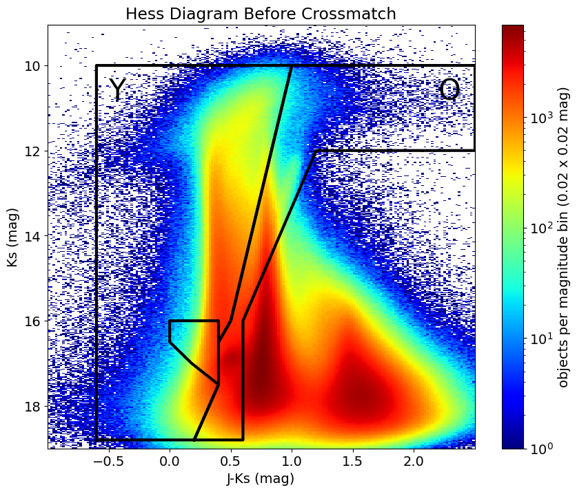

```python
plot_cmd(res['jmkspnt'],res['ksapermag3'],'Hess Diagram Before Crossmatch',extent=(-1,2.5,9,19),binsize=0.02)
```

Compare this plot to Figure 3 (left panel) in [El Youssoufi et al. (2021)](https://arxiv.org/abs/2104.08054). The color scale indicates the stellar density on a logarithmic scale. Stars within the small polygonal area (16 ≤ Ks ≤ 17.5 mag) are not included in the study as they have mixed ages. Enclosed by solid black lines are two different classes of objects: Y referring to young stars and O referring to old stars. The Y and O regions result from the combination of CMD regions established by [El Youssoufi et al. (2019)](https://arxiv.org/abs/1908.08545).

**Region Y:**

- Populated by young stars, including the top of the main sequence and supergiant stars.
- Contains regions A, B, C, I, G, and H from [El Youssoufi et al. (2019)](https://arxiv.org/abs/1908.08545).

**Region O:**

- Populated by old stars, including the red giant branch, asymptotic giant branch, and RC stars.
- Contains regions D, E, J, K, and M from [El Youssoufi et al. (2019)](https://arxiv.org/abs/1908.08545).

**Both regions Y and O:**

- Limited to Ks = 18.8 mag instead of Ks = 19.8 mag, to reflect the sensitivity of the VHS observations.
- Has been extended to Ks = 10 mag, instead of Ks = 11.98 mag and to J-Ks = -0.6 mag instead of J-Ks = -0.2 mag, to maximize the number of stars after their crossmatch with Gaia DR3 (see next plot).

## Query with constraints

Now we query the VHS DR5, Gaia DR3, and pre-computed crossmatch table between VHS DR5 and Gaia DR3 to extract the magnitudes, parallax, and proper motion values with the following constraints:

- Magnitudes exist
- Proper motions exist
- Parallaxes are <=0.2 mas
- Objects are unique (priorsec<=0 or priorsec=framesetid)
- Classified as stars with at least 70% probability (flag mergedclass = −1 or mergedclass = −2)
- Photometric errors are less than 0.2 mag
- RA is between 0 and 130 or between 340 and 360
- Dec is between -119.73 and -39.73

```python
query_xmatch = """
SELECT
    X.ra1 AS ra_vhs, X.dec1 AS dec_vhs,
    (V.jmkspnt - 0.011) AS jmkspnt, (V.ksapermag3 + 0.011) AS ksapermag3,
    G.parallax, G.pmra, G.pmdec
FROM
    vhs_dr5.x1p5__vhs_cat_v3__gaia_dr3__gaia_source AS X
JOIN
    gaia_dr3.gaia_source AS G ON X.id2 = G.source_id
JOIN
    vhs_dr5.vhs_cat_v3 AS V ON X.id1 = V.sourceid
WHERE
    jmkspnt!='NaN' AND ksapermag3 !='NaN' AND japermag3 !='NaN'
    AND parallax<=0.2
    AND (priorsec<=0 OR priorsec = framesetid)
    AND (mergedclass=-1 OR mergedclass=-2)
    AND ksapermag3err<0.2 AND japermag3err<0.2
    AND pmra !='NaN' AND pmdec !='NaN'
    AND pmra BETWEEN -2.25 AND 4.5
    AND pmdec BETWEEN -2.25 AND 2.25
    AND dec1 BETWEEN -119.73 AND -39.73
    AND ((ra1 BETWEEN 0 AND 130) OR (ra1 BETWEEN 340 and 360))
"""

print(query_xmatch) # print the query statement to screen
```

```
SELECT
    X.ra1 AS ra_vhs, X.dec1 AS dec_vhs,
    (V.jmkspnt - 0.011) AS jmkspnt, (V.ksapermag3 + 0.011) AS ksapermag3,
    G.parallax, G.pmra, G.pmdec
FROM
    vhs_dr5.x1p5__vhs_cat_v3__gaia_dr3__gaia_source AS X
JOIN
    gaia_dr3.gaia_source AS G ON X.id2 = G.source_id
JOIN
    vhs_dr5.vhs_cat_v3 AS V ON X.id1 = V.sourceid
WHERE
    jmkspnt!='NaN' AND ksapermag3 !='NaN' AND japermag3 !='NaN'
    AND parallax<=0.2
    AND (priorsec<=0 OR priorsec = framesetid)
    AND (mergedclass=-1 OR mergedclass=-2)
    AND ksapermag3err<0.2 AND japermag3err<0.2
    AND pmra !='NaN' AND pmdec !='NaN'
    AND pmra BETWEEN -2.25 AND 4.5
    AND pmdec BETWEEN -2.25 AND 2.25
    AND dec1 BETWEEN -119.73 AND -39.73
    AND ((ra1 BETWEEN 0 AND 130) OR (ra1 BETWEEN 340 and 360))
```

```python
res_xmatch = qc.query(sql=query_xmatch,fmt='pandas',timeout=600)
res_xmatch
```

|  | ra_vhs | dec_vhs | jmkspnt | ksapermag3 | parallax | pmra | pmdec |
| --- | --- | --- | --- | --- | --- | --- | --- |
| 0 | 340.804983 | -43.131503 | 1.351635 | 17.096413 | 0.018121 | -0.324431 | 0.754686 |
| 1 | 340.547768 | -43.167392 | 0.331964 | 18.311943 | -0.195325 | 1.807555 | -1.156271 |
| 2 | 340.668305 | -43.222689 | 0.220117 | 18.092478 | -0.031267 | 3.888811 | -1.700020 |
| 3 | 340.642725 | -43.147469 | 0.737199 | 17.619534 | -0.229688 | 3.276357 | 1.535750 |
| 4 | 340.360335 | -42.890539 | 0.552765 | 18.500227 | -1.818309 | 1.456224 | -1.786048 |
| ... | ... | ... | ... | ... | ... | ... | ... |
| 1435509 | 40.252425 | -39.841325 | 0.712663 | 17.300019 | 0.035846 | 4.226020 | -0.998021 |
| 1435510 | 39.318568 | -39.784809 | 1.037676 | 16.778429 | -0.208228 | -0.057197 | 0.126042 |
| 1435511 | 39.483259 | -39.798714 | 0.674776 | 16.908503 | -0.022663 | 3.322068 | -0.456721 |
| 1435512 | 42.856933 | -39.913639 | 0.557660 | 14.506774 | 0.027402 | 3.187604 | -1.167838 |
| 1435513 | 39.527807 | -39.890287 | 0.491458 | 15.634467 | -0.037638 | 2.390824 | -1.698996 |

1435514 rows × 7 columns

We can now plot the CMD again, this time post-crossmatching:

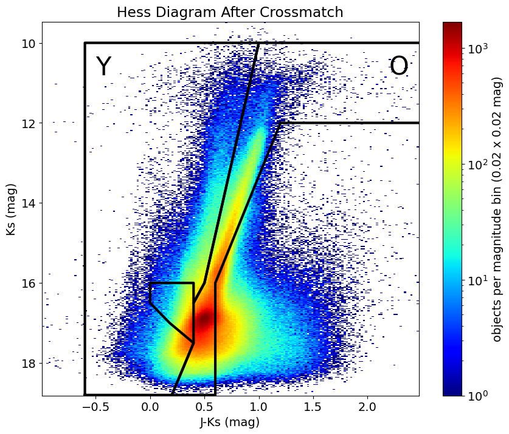

```python
plot_cmd(res_xmatch['jmkspnt'],res_xmatch['ksapermag3'],'Hess Diagram After Crossmatch',extent=(-1,2.5,9,19),binsize=0.02)
```

Compare this plot to Figure 3 (middle panel) in [El Youssoufi et al. (2021)](https://arxiv.org/abs/2104.08054).

## Identifying points only in the Y or O region, then querying for corresponding data

Now we will find points that fall within only the Y polygon region and only the O polygon region. We will use these sets of points to fetch data from the `res_xmatch` table (RA, Dec, parallax, and proper motions). Let's define a helper function:

```python
def get_spatial_selection_mask(x, y, polygon):
    """For a list of x and y coordinates determine whether they are within polygon.

    Parameters
    ----------
    x, y : list
       Lists of x and y coordinates

    polygon : instance
       Instance of shapely.geometry.Polygon

    Returns
    -------
    sel : array
       1D boolean array of same length as `x` and `y`.
       For each (x,y) within polygon, `sel` is True, and False otherwise.
    """

    sel = [True if polygon.contains(Point(xy)) else False for xy in zip(x,y)]

    return np.array(sel)  # returning an array to enable boolean operations later on
```

Below, sel_Y and sel_O are then 1D boolean selection arrays, with True values for every star that is within the corresponding Y or O polygon.

```python
xcol, ycol = 'jmkspnt', 'ksapermag3'  # column names to use
x = res_xmatch[xcol]  # the actual data from these columns
y = res_xmatch[ycol]
sel_Y = get_spatial_selection_mask(x,y,polygon_Y)  # returns a 1D boolean selection array
sel_O = get_spatial_selection_mask(x,y,polygon_O)
```

## Stellar Proper Motions

We examine the stellar density of objects belonging to regions Y and O in proper motion space. We define two ellipses around the LMC and SMC distributions in proper motion space.

```python
LMC_vertices = Ellipse((1.7,0.4),1,2.2,angle=15).get_verts()  # args are: (x0,y0), xwidth, ywidth, angle (in degrees, anti-clockwise)
LMC_ellipse = Polygon(LMC_vertices)  # Turn it into a polygon

SMC_vertices = Ellipse((0.9,-1.2),1.2,0.5).get_verts()
SMC_ellipse = Polygon(SMC_vertices)  # Turn it into a polygon
```

```python
def plot_pm_diagram(x,y,extent=None,binsize=0.006):

    # get number of x and y bins, given the desired binsize
    x, y, nxbins, nybins = compute_nbins(x,y,binsize,extent)

    # plot
    fig, ax = plt.subplots(1,1,figsize=(14,8))
    hmap, xedges, yedges, im = plt.hist2d(x, y, (nxbins, nybins), cmap=plt.cm.jet, norm=LogNorm())
    plt.plot(*LMC_ellipse.exterior.xy,'w',lw=3)
    plt.plot(*SMC_ellipse.exterior.xy,'w',lw=3)
    ax.set_title('Stellar Proper Motion Distributions')
    ax.set_xlabel('$\mu_{RA}$ (mas $yr^{-1}$)')
    ax.set_ylabel('$\mu_{Dec}$ (mas $yr^{-1}$)')
    ax.text(-2,-2,'Y + O',fontsize=30,color='k',family='serif')

    plt.colorbar(im,label=r"objects per bin (%g x %g $\rm mas\,\, yr^{-1}$)" % (binsize,binsize))
```

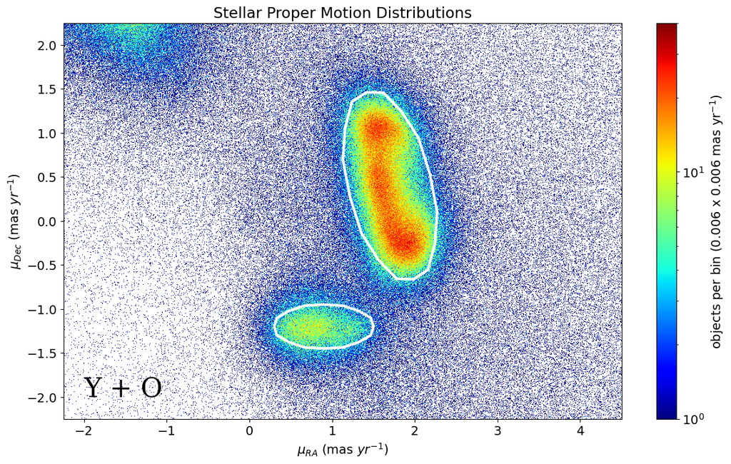

```python
plot_pm_diagram(res_xmatch[sel_Y | sel_O]['pmra'],res_xmatch[sel_Y | sel_O]['pmdec'],binsize=0.006)
```

Compare this plot to Figure 4 in [El Youssoufi et al. (2021)](https://arxiv.org/abs/2104.08054). It shows the stellar proper motions towards the direction of the MCs. Contained within the large and small ellipse are most of the objects with LMC and SMC proper motions, respectively. Many of the objects that fall outside of these ellipses belong to the Milky Way. Objects belonging to these two ellipses make up our morphology dataset, consisting of over 300,000 sources.

#### Now create selection masks for objects within the SMC or LMC proper-motion ellipse, respectively:

```python
sel_pm_SMC = get_spatial_selection_mask(res_xmatch['pmra'],res_xmatch['pmdec'],SMC_ellipse)
sel_pm_LMC = get_spatial_selection_mask(res_xmatch['pmra'],res_xmatch['pmdec'],LMC_ellipse)
```

## Morphology maps of the spatial density of Y, O, and Y+O stars

Next, we will construct the morphology maps of the spatial density of Young, Old, and Young+Old stars using LMC, SMC, and LMC or SMC proper motion selections. First, perform the transformation of coordinates from angular to Cartesian via a zenithal equidistant projection with a projection origin of `ra0=81.24 deg` and `dec0=-69.73 deg` corresponding to the densest point in the LMC bar ([de Vaucouleurs & Freeman 1972](https://ui.adsabs.harvard.edu/abs/1972VA.....14..163D/abstract)).

```python
def zenithal_equidistant_projection(ra,dec):
    """
    Performs the transformation of coordinates from angular to Cartesian
    via a zenithal equidistant projection given a particular point to be
    the origin of analysis (ra0, dec0).
    """
    ra0 = 81.24 * (np.pi/180)   # convert to radians
    dec0 = -69.73 * (np.pi/180)
    ra = ra * (np.pi/180)
    dec = dec * (np.pi/180)

    c = np.arccos( (np.sin(dec0)*np.sin(dec)) + (np.cos(dec0)*np.cos(dec)*np.cos(ra-ra0)) )
    k = c/(np.sin(c))
    x = k * np.cos(dec) * np.sin(ra-ra0)
    y = k * ( (np.cos(dec0)*np.sin(dec)) - (np.sin(dec0)*np.cos(dec)*np.cos(ra-ra0)) )

    X = x * (180/np.pi)   # convert back into degrees
    Y = y * (180/np.pi)

    return X,Y
```

Compute Cartesian X and Y, and add as new columns to the res_xmatch DataFrame:

```python
X,Y = zenithal_equidistant_projection(res_xmatch['ra_vhs'],res_xmatch['dec_vhs'])
res_xmatch['X'] = X
res_xmatch['Y'] = Y
```

#### Creating elliptical masks in the X,Y plane

Here we define two ellipses that will mask the central region of the LMC and SMC to enhance the distribution of stars in the outer regions. We will only want to keep the periphery points (i.e. points that are not contained within the ellipses) for further analysis.

```python
LMC_vertices = Ellipse((0,0.5),12,14).get_verts()  # ((x_center, y_center), width, height)
LMC_mask = Polygon(LMC_vertices)  # Turn it into a polygon

SMC_vertices = Ellipse((-16,-13.5),7.5,7.5).get_verts()
SMC_mask = Polygon(SMC_vertices)

# make selection masks for points within the XY ellipses for LMC and SMC
sel_cart_LMC = get_spatial_selection_mask(res_xmatch['X'],res_xmatch['Y'],LMC_mask)
sel_cart_SMC = get_spatial_selection_mask(res_xmatch['X'],res_xmatch['Y'],SMC_mask)
```

We can now plot the spatial densities of stars outside the SMC and LMC ellipses, but that have proper motions consistent with the MCs, and that have colors and magnitudes within the Y or O polygons:

```python
def plot_spatialdensity(x1,y1,x2,y2,x3,y3,mc):
    '''
    Given the x and y (RA and Dec) coordinates of three different
    regions and the name of the MC (either SMC or LMC, or empty
    string), plot three spatial density morphology maps.
    '''

    # make figure
    fig, axs = plt.subplots(1, 3, figsize=(25,25), sharey=False, sharex=False)

    # plot one panel
    def plotaxis(ax,x,y,bins=130,title=''):
        hist, xedges, yedges = np.histogram2d(x,y,bins=bins)
        extent = [xedges[0], xedges[-1], yedges[0], yedges[-1]]
        r = ax.imshow(hist.T, extent=extent, origin='lower',
                      interpolation='spline16', cmap=plt.get_cmap('jet', 15), vmax=15,)

        ax.set_xlim(20,-30)
        ax.set_ylim(-24,20)
        ax.set_ylabel('$\Delta$ Dec (deg)')
        ax.set_xlabel('$\Delta$ RA (deg)')

        ax.text(0.97,0.9,title,transform=ax.transAxes,ha='right',fontsize=30,color='w',family='serif')
        ax.text(0.97,0.8,mc,transform=ax.transAxes,ha='right',fontsize=20,color='w',family='serif')

        cbar = fig.colorbar(r,ax=ax,shrink=0.21, label='Number of stars per bin')
        cbar.set_ticks([0, 3, 6, 9, 12, 15])

    # plot all panels
    plotaxis(axs[0],x1,y1,title='Y+O')
    plotaxis(axs[1],x2,y2,title='Y')
    plotaxis(axs[2],x3,y3,title='O')

    plt.show()
```

#### Select members and plot:

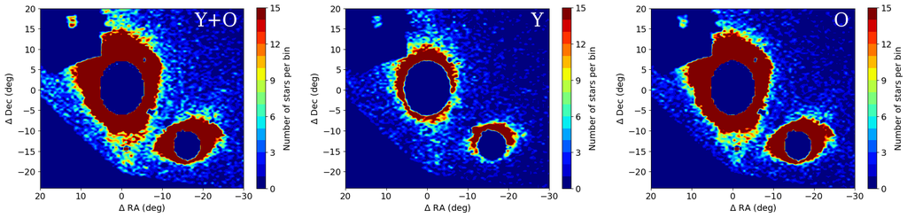

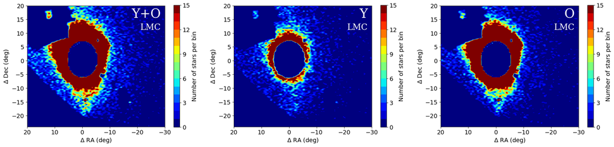

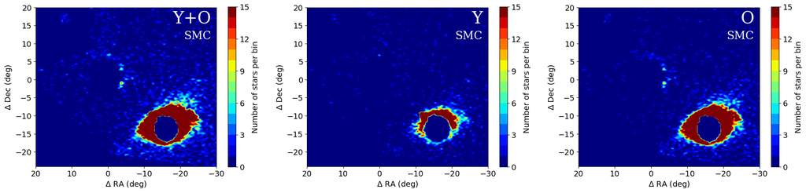

```python
# in either MC PM ellipses, but not in either XY ellipses
sel_MC = (sel_pm_LMC | sel_pm_SMC) & ~sel_cart_LMC & ~sel_cart_SMC
sel_YO_MC = (sel_Y | sel_O) & sel_MC
sel_Y_MC = sel_Y & sel_MC
sel_O_MC = sel_O & sel_MC
plot_spatialdensity(res_xmatch[sel_YO_MC]['X'],res_xmatch[sel_YO_MC]['Y'],
                    res_xmatch[sel_Y_MC]['X'],res_xmatch[sel_Y_MC]['Y'],
                    res_xmatch[sel_O_MC]['X'],res_xmatch[sel_O_MC]['Y'],mc='')

# in LMC PM ellipse, but not in LMC XY ellipse
sel_LMC = sel_pm_LMC & ~sel_cart_LMC
sel_YO_LMC = (sel_Y | sel_O) & sel_LMC
sel_Y_LMC = sel_Y & sel_LMC
sel_O_LMC = sel_O & sel_LMC
plot_spatialdensity(res_xmatch[sel_YO_LMC]['X'],res_xmatch[sel_YO_LMC]['Y'],
                    res_xmatch[sel_Y_LMC]['X'],res_xmatch[sel_Y_LMC]['Y'],
                    res_xmatch[sel_O_LMC]['X'],res_xmatch[sel_O_LMC]['Y'],mc='LMC')

# in SMC PM ellipse, but not in SMC XY ellipse
sel_SMC = sel_pm_SMC & ~sel_cart_SMC
sel_YO_SMC = (sel_Y | sel_O) & sel_SMC
sel_Y_SMC = sel_Y & sel_SMC
sel_O_SMC = sel_O & sel_SMC
plot_spatialdensity(res_xmatch[sel_YO_SMC]['X'],res_xmatch[sel_YO_SMC]['Y'],
                    res_xmatch[sel_Y_SMC]['X'],res_xmatch[sel_Y_SMC]['Y'],
                    res_xmatch[sel_O_SMC]['X'],res_xmatch[sel_O_SMC]['Y'],mc='SMC')
```

Morphology maps of young and old stars (Y+O; left) surrounding the MCs, young stars (Y; middle) dominated by top of main sequence and supergiant stars, and old stars (O; right) dominated RGB and RC stars. The three rows show stars selected based on LMC or SMC proper motions (top), LMC proper motions (middle) and SMC proper motions (bottom). The color bars show the number of stars per bin. The central regions of the LMC and SMC have been masked out to emphasize the distribution of stars in the outer regions.

## Using Gaia DR3 instead of Gaia DR2

The plots and analysis done in [El Youssoufi et al. (2021)](https://arxiv.org/abs/2104.08054) used Gaia DR2 to extract the parallax and proper motion values for stars surrounding the Magellanic Clouds. This notebook instead uses Gaia DR3, which has better astrometry and less noisy flux measurements to show better quality results.

Compare the image below (which uses Gaia DR2 to plot the morphology maps) with the plot above (which uses Gaia DR3). There is a clear improvement in data collected for the LMC and SMC. Particularly in the bottom row, which is supposed to show only the SMC, shows less of an imprint for the LMC.

[figure not shown]

# Resources & references

Interpolations for imshow: https://matplotlib.org/stable/gallery/images_contours_and_fields/interpolation_methods.html  
Shapely: https://shapely.readthedocs.io/en/stable/manual.html  
Azimuthal Equidistant Projection: https://mathworld.wolfram.com/AzimuthalEquidistantProjection.html

Cioni et al. (2014): https://arxiv.org/abs/1306.4336  
Cioni et al. (2016): https://arxiv.org/abs/1510.07647  
El Youssoufi et al. (2019): https://arxiv.org/abs/1908.08545  
El Youssoufi et al. (2021): https://arxiv.org/abs/2104.08054